# Stat. 674 Project

Author

Deepak_Gugulla

Published

February 24, 2025

## Class Project

For the COVID19 data from United States develop the best forecasting models for *confirmed* cases and produce a forecast for the next 30 days, after the end of the available data. Note that the data is recorded daily.

See Section 9.11 Exercises 10 for an example.

```r
library(pacman)
p_load(tidyverse, fpp3, COVID19)
```

```r
covid_data <- covid19(c("United States"))
```

[output not shown]

```r
covid_data <- covid_data %>% as_tsibble(key = "id", index = "date")
```

> 1. Produce an STL decomposition of the data and describe the trend and seasonality.

First determine when the start and end of the available data for the *confirmed* cases.

### **Code and Comments:**

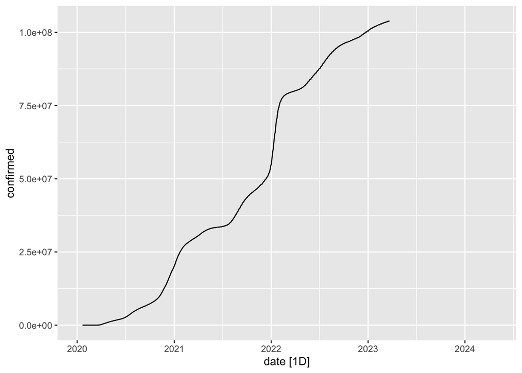

```r
covid_data %>% autoplot(confirmed)
```

```r
# Load necessary libraries
library(pacman)
p_load(tidyverse, fpp3, COVID19)

# Load COVID-19 data for the United States
covid_data <- covid19("United States")
```

[output not shown]

```r
# Convert to a tsibble
covid_data <- covid_data %>% as_tsibble(key = "id", index = "date")
covid_data <- covid_data %>%
  drop_na(confirmed)

# Check start and end dates for confirmed cases
covid_data %>%
  summarise(Start_Date = min(date), End_Date = max(date))
```

| date | Start_Date | End_Date |
| --- | --- | --- |
| 2020-01-21 | 2020-01-21 | 2020-01-21 |
| 2020-01-22 | 2020-01-22 | 2020-01-22 |
| 2020-01-23 | 2020-01-23 | 2020-01-23 |
| 2020-01-24 | 2020-01-24 | 2020-01-24 |
| 2020-01-25 | 2020-01-25 | 2020-01-25 |
| 2020-01-26 | 2020-01-26 | 2020-01-26 |
| 2020-01-27 | 2020-01-27 | 2020-01-27 |
| 2020-01-28 | 2020-01-28 | 2020-01-28 |
| 2020-01-29 | 2020-01-29 | 2020-01-29 |
| 2020-01-30 | 2020-01-30 | 2020-01-30 |

[output cut: 1148 more lines]

| date <date> | Start_Date <date> | End_Date <date> |  |  |
| --- | --- | --- | --- | --- |
| 2020-01-21 | 2020-01-21 | 2020-01-21 |  |  |
| 2020-01-22 | 2020-01-22 | 2020-01-22 |  |  |
| 2020-01-23 | 2020-01-23 | 2020-01-23 |  |  |
| 2020-01-24 | 2020-01-24 | 2020-01-24 |  |  |
| 2020-01-25 | 2020-01-25 | 2020-01-25 |  |  |
| 2020-01-26 | 2020-01-26 | 2020-01-26 |  |  |
| 2020-01-27 | 2020-01-27 | 2020-01-27 |  |  |
| 2020-01-28 | 2020-01-28 | 2020-01-28 |  |  |
| 2020-01-29 | 2020-01-29 | 2020-01-29 |  |  |
| 2020-01-30 | 2020-01-30 | 2020-01-30 |  |  |

...

1-10 of 1,158 rows

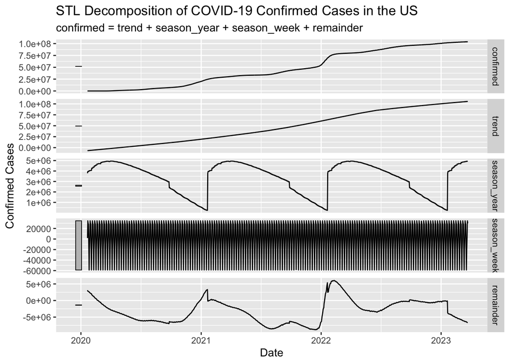

```r
# STL decomposition of confirmed cases
covid_data %>%
  model(STL(confirmed ~ season(window = "periodic"))) %>%
  components() %>%
  autoplot() +
  labs(title = "STL Decomposition of COVID-19 Confirmed Cases in the US",
       y = "Confirmed Cases", x = "Date")
```

> 2. Do the data need transforming? If so, find a suitable transformation.

### **Answer:**

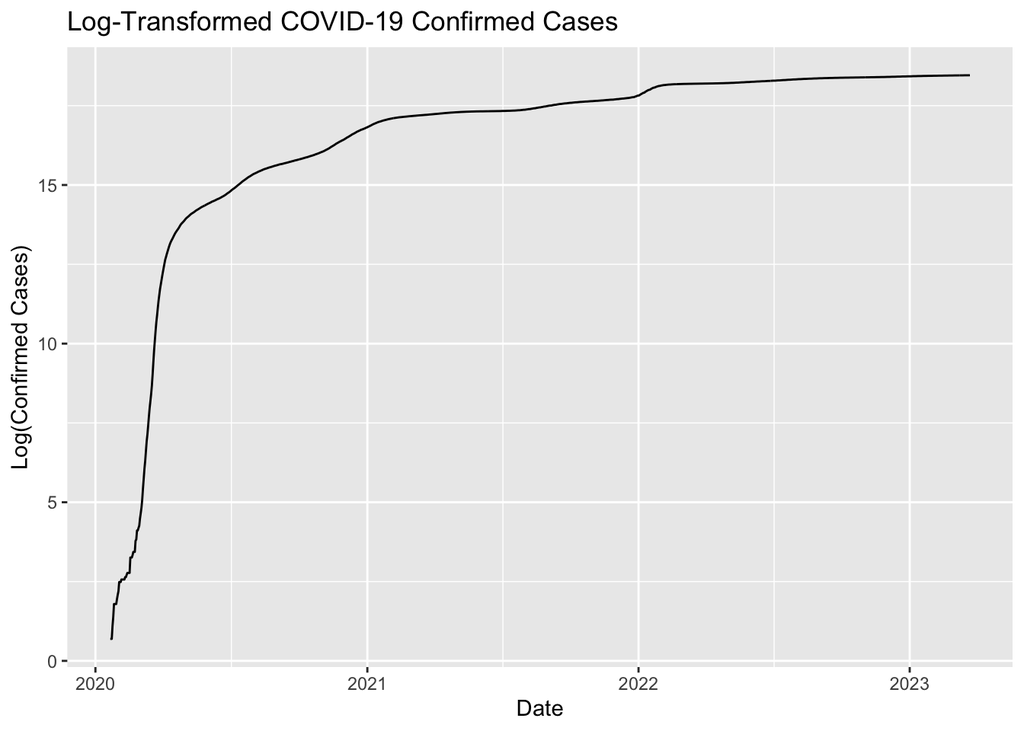

```r
# Apply log transformation to stabilize variance
covid_data <- covid_data %>%
  mutate(log_confirmed = log(confirmed + 1))  # Adding 1 to avoid log(0) issue

# Plot transformed data
covid_data %>%
  autoplot(log_confirmed) +
  labs(title = "Log-Transformed COVID-19 Confirmed Cases", y = "Log(Confirmed Cases)", x = "Date")
```

> 3. Are the data approximately stationary? If not, find an appropriate differencing which yields approximately stationary data.

Try differencing. Try differencing twice. It may not be possible to transform the data to get the data to have both constant mean and constant variance. Try to get at least a constant mean.

### **Code and Comments:**

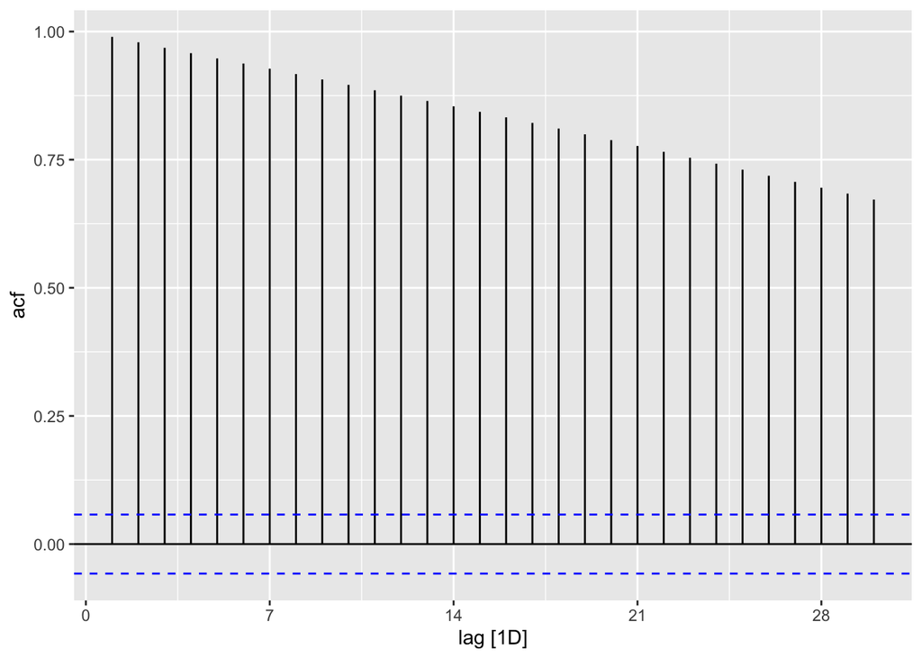

```r
# Load necessary libraries
library(fpp3)

# Perform ACF plot to check for stationarity
covid_data %>%
  ACF(log_confirmed) %>%
  autoplot()
```

```r
# KPSS test for stationarity
covid_data %>%
  features(log_confirmed, unitroot_kpss)
```

| id | kpss_stat | kpss_pvalue |
| --- | --- | --- |
| 59a13ceb | 7.173464 | 0.01 |

| id <chr> | kpss_stat <dbl> | kpss_pvalue <dbl> |  |  |
| --- | --- | --- | --- | --- |
| 59a13ceb | 7.173464 | 0.01 |  |  |

1 row

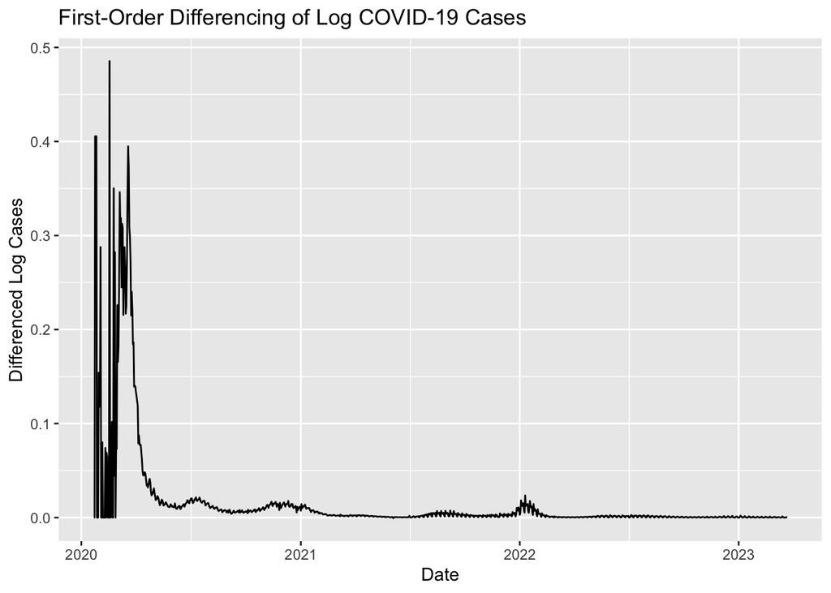

```r
# First-order differencing
covid_data <- covid_data %>%
  mutate(diff_log_confirmed = difference(log_confirmed))

# Plot differenced data
covid_data %>%
  autoplot(diff_log_confirmed) +
  labs(title = "First-Order Differencing of Log COVID-19 Cases",
       y = "Differenced Log Cases", x = "Date")
```

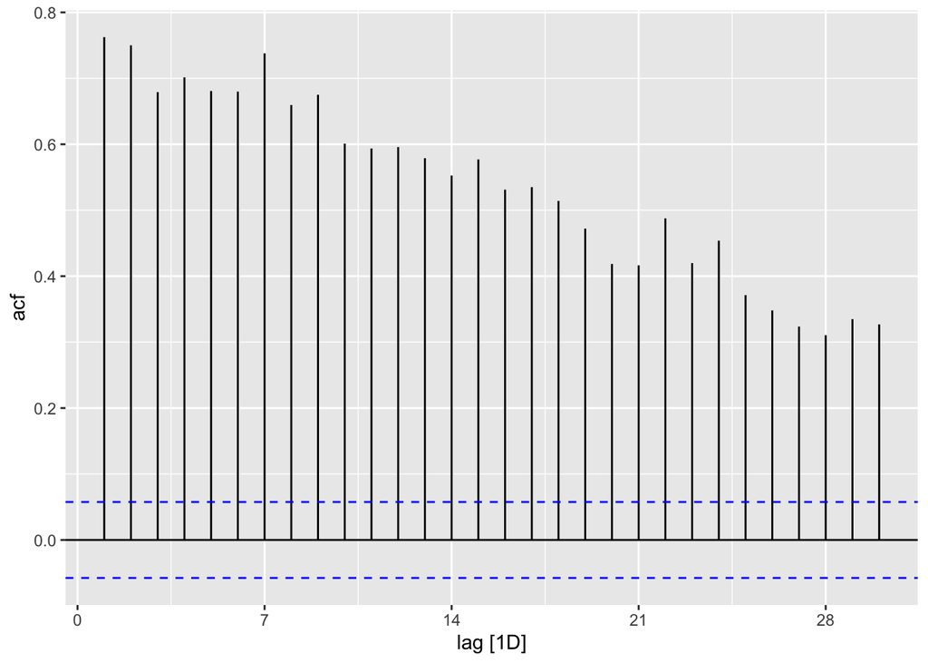

```r
# ACF plot to check if differencing is sufficient
covid_data %>%
  ACF(diff_log_confirmed) %>%
  autoplot()
```

[figure not shown]

```r
# First-order differencing
covid_data <- covid_data %>%
  mutate(diff_log_confirmed = difference(log_confirmed))

# Plot differenced data
covid_data %>%
  autoplot(diff_log_confirmed) +
  labs(title = "First-Order Differencing of Log COVID-19 Cases",
       y = "Differenced Log Cases", x = "Date")
```

[figure not shown]

```r
# ACF plot to check if differencing is sufficient
covid_data %>%
  ACF(diff_log_confirmed) %>%
  autoplot()
```

> 4. Identify two ARIMA models that might be useful in describing the time series. Which of your models is the best according to their AICc values?